# DYOCA

*..or "An empiracal analysis of fees and transactions believed to be payments"*  
@josibake - Coinbase 2022 Developer Grantee  
@ClaraShik - Postdoc Researcher, Chaincode Labs

Joint work with:  
Gur Huberman - Columbia University  
Paolo Guasoni - Dublin University

## Things we are interested in

- Payments over Bitcoin – dynamics of user and wallet behavior
- Fees – a good statistical model, and general behavior description
- Structural changes of wallet behavior
- Privacy – anything we can find, anyone else can (fix!)

## How we are doing this

- Read from Google BigQuery [Bitcoin public datasets](https://cloud.google.com/blog/products/data-analytics/introducing-six-new-cryptocurrencies-in-bigquery-public-datasets-and-how-to-analyze-them)
- Run our DataFlow pipeline to process and identify transactions
- Publish as a BigQuery table for analysis
- https://github.com/josibake/bitcoin-data-pipelines

## How we are doing this

[figure not shown]

# transactions that are believed to be payments

- Transactions with two or less outputs (TX2OL)
- Considered *most likely*
- Does this transaction set have enough volume and economic value to be worth studying?
- Yes, about 80% of value being transacted from 2010 - 2021 (next slide - yes with a graph)

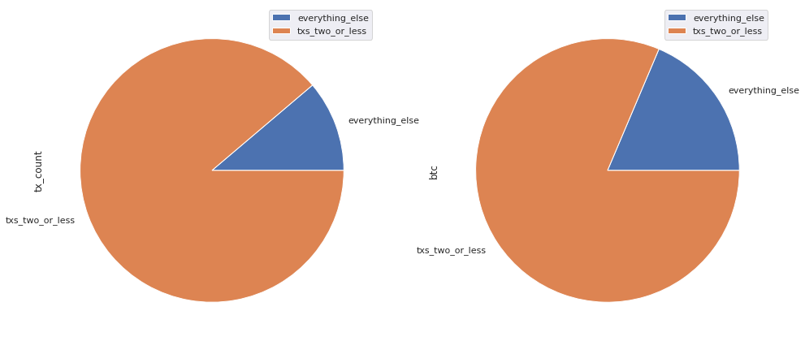

## Determing the payment value

*finding the change transaction*

- Single Output
- Return Change To Input Address
- Matching Address Type
- Previously Seen Address
- Nonstandard
- Unknown

In the following graph we can already see some interesting things

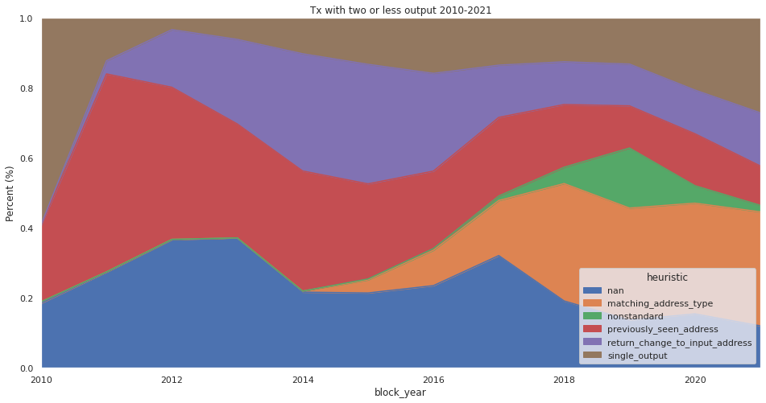

## USD value of transactions

- Excluding single output and nonstandard, we consider the mean and median USD value over time
- Payment value, this seems to fall with in a reasonable range for a "retail payment."
- Change values tend to be higher valued

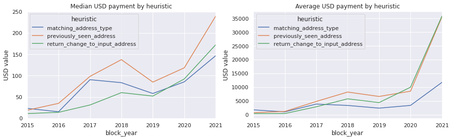

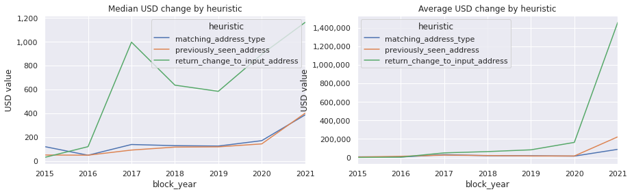

## Mempool snapshots

- For each Tx, include when first seen in the mempool
- How many Tx are seen but never mined
- How many Tx are mined but never seen
- Congestion, fee analysis, etc

## 2021-01-01 Txs with mempool data

[figure not shown]

## 2021-01-01 Txs with mempool data

[figure not shown]

## Questions / discussion

- Feedback on approach
- Research questions
- Additional data sources
- Additional heuristics
- Accessibility